# Selected Sections from Chapter 10: 10.3

[figure not shown]

© Scott Robison 2021 all rights reserved.

## Single Sample Hypothesis test for Large and Normally Distributed Data

> Start by [Reading](https://github.com/chqngh-berkeley/personal/blob/master/Mathematical%20Statistics%20-%207th%20Edition%20-%20Wackerly.pdf) pages 496-501 from the text.

Recall the Estimators/Statistics/Pivotal Quantities that we used to create confidence intervals:

- **$(1-\alpha)100$% Confidence Interval for $\mu$, when $\sigma$ is known:**

For pivotal quantity: $Z=\frac{\overline{X}-\mu}{\frac{\sigma}{\sqrt{n}}}\sim Norm(0,1)$

where $\overline{X} =\frac{\sum_{i=1}^n X_i }{n}$ when $X_i$ is an I.I.D. sample and either $X_i\sim Norm(\mu,\sigma)$ or $n$ is large enough for the central limit theorem to reasonably approximate that $\overline{X} \sim Norm \bigg(\mu,\frac{\sigma}{\sqrt{n}}\bigg)$

- **$(1-\alpha)100$% Confidence Interval for $\mu$, when $\sigma$ is unknown:**

where $\overline{X} =\frac{\sum_{i=1}^n X_i }{n}$ when $X_i$ is an I.I.D. sample and either $X_i\sim Norm(\mu,\sigma)$ or $n$ is large enough for the central limit theorem to reasonably approximate that $\overline{X} \sim Norm \bigg(\mu,\frac{\sigma}{\sqrt{n}}\bigg)$

- **$(1-\alpha)100$% Confidence Interval for $p$, when $p$ is unknown:**

For pivotal quantity: $Z=\frac{\widehat{p}-p}{\sqrt{\frac{\widehat{p}(1-\widehat{p})}{n}}}\sim Norm(0,1)$

where $\widehat{p} =\frac{\sum_{i=1}^n X_i }{n}$ when $X_i$ is an I.I.D. sample and either $X_i\sim Bern(p)$ or $n$ is large enough for the central limit theorem to reasonably approximate that $\widehat{p} \sim Norm \Bigg(np,\sqrt{\frac{p(1-p)}{n}}\Bigg)$

- **$(1-\alpha)100$% Confidence Interval for $\sigma$:**

For pivotal quantity: $\frac{(n-1) S^2}{\sigma^2} \sim \chi_{df=n-1}^2$

where $S^2=\frac{\sum_{i=1}^n(X_i-\overline{X} )^2 }{n-1}$ when $X_i$ is an I.I.D. sample and either $X_i\sim Norm(\mu,\sigma)$ or $n$ is large enough for the central limit theorem to reasonably approximate that $\overline{X} \sim Norm \bigg(\mu,\frac{\sigma}{\sqrt{n}}\bigg)$

Confidence interval theory is exceedingly close to the idea for hypothesis testing! However, instead of building margins of error on to point estimates to estimate parameter(s), we hypothesize what the parameter(s) are then, measure the probability of how well the sample data “fits” that hypothesis.

**Many of the formulas and code we have already derived are still very useful!** Others will only be slightly altered to suit our needs.

The first change that we will need to make to our “old” confidence intervals is to replace the parameter(s) with hypothesis notation. In place of a general parameter $\theta$ will sub in $\theta_0$ this notation clearly references that this value is the current/original/null belief that we old for $\theta$ and should remind the reader this value is stated in the null hypothesis, $H_0$.

Therefore, for hypothesis testing $\mu=\mu_0$, (when estimating $\mu$), $p=p_0$, (when estimating $p$), and $\sigma=\sigma_0$, (when estimating $\sigma$) etc.

### Lower, Upper, and Two Tailed Hypothesis test Recall: $\alpha=P (\text{inferring }H_0 \text{ is incorrect}|H_0 \text{ is correct})$

$$\begin{align}
& H_0:\theta=\theta_0,& H_0:\theta=\theta_0,&& H_0:\theta=\theta_0\\
& H_a:\theta<\theta_0,& H_a:\theta>\theta_0,&& H_a:\theta\ne\theta_0\\
\end{align}$$

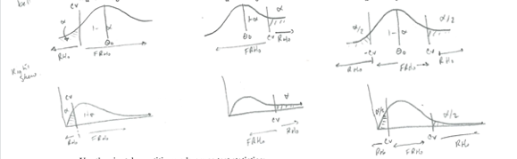

### Use the pivotal quantities we knew as test statistics:

Recall: p-value=$P(f_X (x)[(\ne,>,<)\text{ sign in alternative hyp.}] X |H_0 \text{ is true})$ where $X$ is the test Statistic

$$Z_{calc}=\frac{\overline{X}-\mu}{\frac{\sigma}{\sqrt{n}}}\sim Norm(0,1)$$

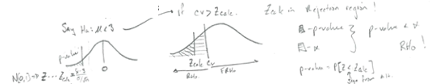

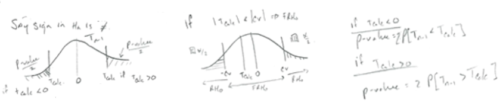

$$Z_{calc}=\frac{\widehat{p}-p}{\sqrt{\frac{\widehat{p}(1-\widehat{p})}{n}}}\sim Norm(0,1)$$

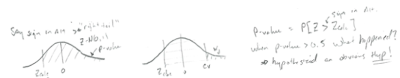

$$\chi^2_{calc}=\frac{(n-1) S^2}{\sigma^2} \sim \chi_{df=n-1}^2$$

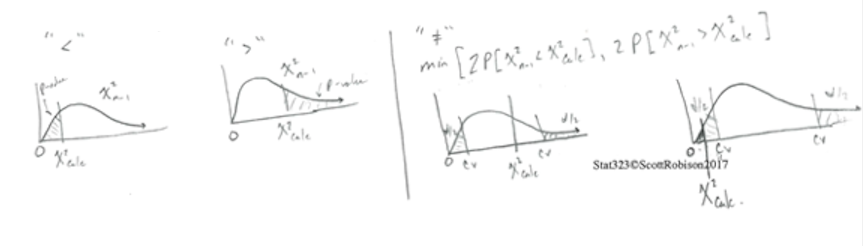

[video not shown]

Looking for [R code provided in Examples? right click “save linked file”](https://people.ucalgary.ca/~sarobiso/323/text%20soltutions/Single%20Sample%20Hyp1.R)

### Example 1

A recent Freedom of Information and Privacy request made by The Calgary Herald seemed to indicate that teachers working with the Calgary Board of Education (CBE) take more sick days than ‘other occupations’. Statistics Canada reports that the mean number of sick days (a sick day being taken due to illness, disability, personal reasons, or family responsibilities) taken for all occupations (excluding teachers) was 8.8 days per year.

A random sample of $n = 250$ teachers working in the CBE in was taken and the number sick days taken between December 1, 2013 and December 1, 2014 was reported. The mean was 10.1 sick days. Assuming that the standard deviation in the number of sick days taken by all CBE teachers was 3.2.

1. Does the data indicate that, on average, teachers working in the CBE took more sick days compared to people working in all other occupations? Use $\alpha = 0.05.$
2. Interpret the meaning of the P-value found in (a).

### Solution

[video not shown]

### Example 2

One wanted to see if the mean amount of time it takes one to pass through US Customs at the Calgary International Airport between 06:00 and 09:00 on a weekday morning is less than 60 minutes. Ten customers, whose flights left for US destinations, were randomly chosen in each of five weekdays. The amount of time it took each to clear US Customs after they had entered the airline queue for their respective flight was observed. From this sample of 50, the mean amount of time was observed to be 57.5 minutes the standard deviation was observed to be 10.2 minutes.

1. Does this sample indicate that the mean amount of time it takes one to pass through US Customs at the Calgary International Airport (between 6AM and 9AM on a weekday) is less than 60 minutes? Test, setting the probability of making a Type I error to be 0.05.
2. Interpret the meaning of the P-value found in (a).

### Solution

Please try this on your own before looking at the [solution](https://people.ucalgary.ca/~sarobiso/323/text%20soltutions/Single%20hyp%20ex%202.pdf)

### Example 3

Factory workers produce an average of 12 electronics circuits/day. A new incentive program is introduced to increase the daily output. A random sample of 30 workers, in the new incentive program for a month, was taken and their output on a randomly selected day was recorded. The mean and standard deviation of the sample was 12.9 and 1.2, respectively. Does this data suggest that the new incentive program does increase output? Test at a level of significance of 5%. and interpret the meaning of the P-value.

### Solution

[video not shown]

### Example 4

Recently, a national airline claimed that ‘at a minimum, 92% of our flights are on-time.’ To test this claim, a statistician randomly selected 200 of this airline’s flights, observing if each flight was ‘on-time’ or ‘not’. 181 of the 200 flights arrived to their destination on-time. Conduct the appropriate test regulating the probability of committing a Type I error to be 5%, and base the decision on the P-value.

### Solution

Please try this on your own before looking at the [solution](https://people.ucalgary.ca/~sarobiso/323/text%20soltutions/single%20hyp%20ex%204.pdf)

### Example 5

The precision of an instrument is its ability to make repeated measurements that closely agree. One measure of precision is the variance among the repeated measurements: the smaller the variation in the measurements, the greater the precision. An advertised claim for a thermometer is that the standard deviation in its measurements is at most 0.1 degrees Celsius. It is suspected that this thermometer hare more variance.

A sample of 10 repeated measurements was taken of a controlled temperature bath, producing a standard deviation in the 10 measurements of 0.141. Does this support the advertised claim? Test at $\alpha = 0.05$.

### Solution

[video not shown]

### Example 6

Does one’s educational level influence their opinion about vaccinations? A recent Angus Reid survey was taken. Each person sampled was asked to respond to the statement “The science around vaccinations isn’t clear.” Respondents ‘strongly agree’, ’moderately agree’, ’moderately disagree’, or ’strongly disagree’. Of the $n = 1509$ people sampled, $n = 376$ of had at least an undergraduate university education. Of these, 274 ‘disagreed’. A similar study concluded that of those less educated Canadians (high school or less), 55% disagree with this statement.

Does this data indicate that the proportion of Canadians having a university-level education who disagree with the ‘science of vaccinations isn’t clear’ statement higher than the proportion of Canadians who are less educated (high school or less)? Test, regulating the probability of committing a Type I error to be 0.05.

### Solution

Please try this on your own before looking at the [solution](https://people.ucalgary.ca/~sarobiso/323/text%20soltutions/single%20hyp%20ex%206.pdf)

> Please [**Practice**](https://github.com/chqngh-berkeley/personal/blob/master/Mathematical%20Statistics%20-%207th%20Edition%20-%20Wackerly.pdf) as many exercises from pages 501-507 as possible the odd questions have answers in the back of the text.

> This is where the real learning happens.